# Data Science

Julia, Cristian

2024-02-19

```r
datosMH <- read.csv("data/2.globalTrendsinMentalHealth/Mental health Depression disorder Data2.csv")
head(datosMH)
```

```
##   index      Entity Code Year Schizophrenia Bipolar.disorders Eating.disorders
## 1     0 Afghanistan  AFG 1990       0.16056          0.697779         0.101855
## 2     1 Afghanistan  AFG 1991      0.160312          0.697961         0.099313
## 3     2 Afghanistan  AFG 1992      0.160135          0.698107         0.096692
## 4     3 Afghanistan  AFG 1993      0.160037          0.698257         0.094336
## 5     4 Afghanistan  AFG 1994      0.160022          0.698469         0.092439
## 6     5 Afghanistan  AFG 1995      0.160076          0.698695          0.09098
##   Anxiety.disorders Drug.use.disorders Depression Alcohol.use.disorders
## 1          4.828830           1.677082   4.071831              0.672404
## 2          4.829740           1.684746   4.079531              0.671768
## 3          4.831108           1.694334   4.088358              0.670644
## 4          4.830864           1.705320   4.096190              0.669738
## 5          4.829423           1.716069   4.099582              0.669260
## 6          4.828337           1.728112   4.104207              0.668746
```

Para mantener una cohesión y una mejor organización del conjunto de datos, decidimos eliminar la columna “index” pues el entorno de programación ya tiene en cuenta una columna para el índice.

```r
# Eliminación de la columna 'index'
datosMH <- subset(datosMH, select = -index)
```

```r
summary(datosMH)
```

```
##     Entity              Code               Year           Schizophrenia
##  Length:108553      Length:108553      Length:108553      Length:108553
##  Class :character   Class :character   Class :character   Class :character
##  Mode  :character   Mode  :character   Mode  :character   Mode  :character
##
##
##
##
##  Bipolar.disorders  Eating.disorders   Anxiety.disorders Drug.use.disorders
##  Length:108553      Length:108553      Min.   :2.02      Min.   :0.38
##  Class :character   Class :character   1st Qu.:3.20      1st Qu.:0.53
##  Mode  :character   Mode  :character   Median :3.56      Median :0.72
##                                        Mean   :4.00      Mean   :0.86
##                                        3rd Qu.:4.68      3rd Qu.:0.94
##                                        Max.   :8.97      Max.   :3.45
##                                        NA's   :102141    NA's   :102141
##    Depression     Alcohol.use.disorders
##  Min.   :2.14     Min.   :0.45
##  1st Qu.:2.99     1st Qu.:0.99
##  Median :3.51     Median :1.48
##  Mean   :3.50     Mean   :1.58
##  3rd Qu.:3.92     3rd Qu.:1.86
##  Max.   :6.60     Max.   :5.47
##  NA's   :102141   NA's   :102141
```

```r
str(datosMH)
```

```
## 'data.frame':    108553 obs. of  10 variables:
##  $ Entity               : chr  "Afghanistan" "Afghanistan" "Afghanistan" "Afghanistan" ...
##  $ Code                 : chr  "AFG" "AFG" "AFG" "AFG" ...
##  $ Year                 : chr  "1990" "1991" "1992" "1993" ...
##  $ Schizophrenia        : chr  "0.16056" "0.160312" "0.160135" "0.160037" ...
##  $ Bipolar.disorders    : chr  "0.697779" "0.697961" "0.698107" "0.698257" ...
##  $ Eating.disorders     : chr  "0.101855" "0.099313" "0.096692" "0.094336" ...
##  $ Anxiety.disorders    : num  4.83 4.83 4.83 4.83 4.83 ...
##  $ Drug.use.disorders   : num  1.68 1.68 1.69 1.71 1.72 ...
##  $ Depression           : num  4.07 4.08 4.09 4.1 4.1 ...
##  $ Alcohol.use.disorders: num  0.672 0.672 0.671 0.67 0.669 ...
```

datosMH:

index: Un índice numérico. Entity: El país o entidad asociada con los datos. Code: El código del país. Year: El año al que pertenecen los datos. Schizophrenia, Bipolar.disorders, Eating.disorders, Anxiety.disorders, Drug.use.disorders, Depression, Alcohol.use.disorders: Diferentes tipos de trastornos de salud mental y sus tasas correspondientes.

Tamaño del conjunto: 108553

```r
missing_values_mh <- colSums(is.na(datosMH))
print("Datos faltantes en datosMH:")
```

```
## [1] "Datos faltantes en datosMH:"
```

```r
print(missing_values_mh)
```

```
##                Entity                  Code                  Year
##                     0                     0                     0
##         Schizophrenia     Bipolar.disorders      Eating.disorders
##                     0                     0                     0
##     Anxiety.disorders    Drug.use.disorders            Depression
##                102141                102141                102141
## Alcohol.use.disorders
##                102141
```

```r
datosMH1 <- datosMH[1:6468, ]
datosMH2 <- datosMH[6469:54276, ]
datosMH3 <- datosMH[54277:102084, ]
datosMH4 <- datosMH[102085: nrow(datosMH), ]

head(datosMH1)
```

```
##        Entity Code Year Schizophrenia Bipolar.disorders Eating.disorders
## 1 Afghanistan  AFG 1990       0.16056          0.697779         0.101855
## 2 Afghanistan  AFG 1991      0.160312          0.697961         0.099313
## 3 Afghanistan  AFG 1992      0.160135          0.698107         0.096692
## 4 Afghanistan  AFG 1993      0.160037          0.698257         0.094336
## 5 Afghanistan  AFG 1994      0.160022          0.698469         0.092439
## 6 Afghanistan  AFG 1995      0.160076          0.698695          0.09098
##   Anxiety.disorders Drug.use.disorders Depression Alcohol.use.disorders
## 1          4.828830           1.677082   4.071831              0.672404
## 2          4.829740           1.684746   4.079531              0.671768
## 3          4.831108           1.694334   4.088358              0.670644
## 4          4.830864           1.705320   4.096190              0.669738
## 5          4.829423           1.716069   4.099582              0.669260
## 6          4.828337           1.728112   4.104207              0.668746
```

```r
head(datosMH2)
```

```
##           Entity Code Year           Schizophrenia         Bipolar.disorders
## 6469      Entity Code Year Prevalence in males (%) Prevalence in females (%)
## 6470 Afghanistan  AFG 1800
## 6471 Afghanistan  AFG 1801
## 6472 Afghanistan  AFG 1802
## 6473 Afghanistan  AFG 1803
## 6474 Afghanistan  AFG 1804
##      Eating.disorders Anxiety.disorders Drug.use.disorders Depression
## 6469       Population                NA                 NA         NA
## 6470          3280000                NA                 NA         NA
## 6471          3280000                NA                 NA         NA
## 6472          3280000                NA                 NA         NA
## 6473          3280000                NA                 NA         NA
## 6474          3280000                NA                 NA         NA
##      Alcohol.use.disorders
## 6469                    NA
## 6470                    NA
## 6471                    NA
## 6472                    NA
## 6473                    NA
## 6474                    NA
```

```r
head(datosMH3)
```

```
##            Entity Code Year                                Schizophrenia
## 54277      Entity Code Year Suicide rate (deaths per 100000 individuals)
## 54278 Afghanistan  AFG 1800
## 54279 Afghanistan  AFG 1801
## 54280 Afghanistan  AFG 1802
## 54281 Afghanistan  AFG 1803
## 54282 Afghanistan  AFG 1804
##                                             Bipolar.disorders Eating.disorders
## 54277 Depressive disorder rates (number suffering per 100000)       Population
## 54278                                                                  3280000
## 54279                                                                  3280000
## 54280                                                                  3280000
## 54281                                                                  3280000
## 54282                                                                  3280000
##       Anxiety.disorders Drug.use.disorders Depression Alcohol.use.disorders
## 54277                NA                 NA         NA                    NA
## 54278                NA                 NA         NA                    NA
## 54279                NA                 NA         NA                    NA
## 54280                NA                 NA         NA                    NA
## 54281                NA                 NA         NA                    NA
## 54282                NA                 NA         NA                    NA
```

```r
head(datosMH4)
```

```
##             Entity Code Year
## 102085      Entity Code Year
## 102086 Afghanistan  AFG 1990
## 102087 Afghanistan  AFG 1991
## 102088 Afghanistan  AFG 1992
## 102089 Afghanistan  AFG 1993
## 102090 Afghanistan  AFG 1994
##                                                                                                    Schizophrenia
## 102085 Prevalence - Depressive disorders - Sex: Both - Age: All Ages (Number) (people suffering from depression)
## 102086                                                                                              318435.81367
## 102087                                                                                             329044.773956
## 102088                                                                                             382544.572895
## 102089                                                                                             440381.507393
## 102090                                                                                             456916.645489
##        Bipolar.disorders Eating.disorders Anxiety.disorders Drug.use.disorders
## 102085                                                   NA                 NA
## 102086                                                   NA                 NA
## 102087                                                   NA                 NA
## 102088                                                   NA                 NA
## 102089                                                   NA                 NA
## 102090                                                   NA                 NA
##        Depression Alcohol.use.disorders
## 102085         NA                    NA
## 102086         NA                    NA
## 102087         NA                    NA
## 102088         NA                    NA
## 102089         NA                    NA
## 102090         NA                    NA
```

```r
#Preprocesamiento datosMH2
colnames(datosMH2) <- datosMH2[1,]
datosMH2 <- subset(datosMH2, select = -c(7:10))
datosMH2 <- tail(datosMH2, -1)
rownames(datosMH2) <- NULL

#Preprocesamiento datosMH3
colnames(datosMH3) <- datosMH3[1,]
datosMH3 <- subset(datosMH3, select = -c(7:10))
datosMH3 <- tail(datosMH3, -1)
rownames(datosMH3) <- NULL

#Preprocesamiento datosMH4
colnames(datosMH4) <- datosMH4[1,]
datosMH4 <- subset(datosMH4, select = -c(5:10))
datosMH4 <- tail(datosMH4, -1)
rownames(datosMH4) <- NULL

head(datosMH1)
```

```
##        Entity Code Year Schizophrenia Bipolar.disorders Eating.disorders
## 1 Afghanistan  AFG 1990       0.16056          0.697779         0.101855
## 2 Afghanistan  AFG 1991      0.160312          0.697961         0.099313
## 3 Afghanistan  AFG 1992      0.160135          0.698107         0.096692
## 4 Afghanistan  AFG 1993      0.160037          0.698257         0.094336
## 5 Afghanistan  AFG 1994      0.160022          0.698469         0.092439
## 6 Afghanistan  AFG 1995      0.160076          0.698695          0.09098
##   Anxiety.disorders Drug.use.disorders Depression Alcohol.use.disorders
## 1          4.828830           1.677082   4.071831              0.672404
## 2          4.829740           1.684746   4.079531              0.671768
## 3          4.831108           1.694334   4.088358              0.670644
## 4          4.830864           1.705320   4.096190              0.669738
## 5          4.829423           1.716069   4.099582              0.669260
## 6          4.828337           1.728112   4.104207              0.668746
```

```r
head(datosMH2)
```

```
##        Entity Code Year Prevalence in males (%) Prevalence in females (%)
## 1 Afghanistan  AFG 1800
## 2 Afghanistan  AFG 1801
## 3 Afghanistan  AFG 1802
## 4 Afghanistan  AFG 1803
## 5 Afghanistan  AFG 1804
## 6 Afghanistan  AFG 1805
##   Population
## 1    3280000
## 2    3280000
## 3    3280000
## 4    3280000
## 5    3280000
## 6    3280000
```

```r
head(datosMH3)
```

```
##        Entity Code Year Suicide rate (deaths per 100000 individuals)
## 1 Afghanistan  AFG 1800
## 2 Afghanistan  AFG 1801
## 3 Afghanistan  AFG 1802
## 4 Afghanistan  AFG 1803
## 5 Afghanistan  AFG 1804
## 6 Afghanistan  AFG 1805
##   Depressive disorder rates (number suffering per 100000) Population
## 1                                                            3280000
## 2                                                            3280000
## 3                                                            3280000
## 4                                                            3280000
## 5                                                            3280000
## 6                                                            3280000
```

```r
head(datosMH4)
```

```
##        Entity Code Year
## 1 Afghanistan  AFG 1990
## 2 Afghanistan  AFG 1991
## 3 Afghanistan  AFG 1992
## 4 Afghanistan  AFG 1993
## 5 Afghanistan  AFG 1994
## 6 Afghanistan  AFG 1995
##   Prevalence - Depressive disorders - Sex: Both - Age: All Ages (Number) (people suffering from depression)
## 1                                                                                              318435.81367
## 2                                                                                             329044.773956
## 3                                                                                             382544.572895
## 4                                                                                             440381.507393
## 5                                                                                             456916.645489
## 6                                                                                             471475.201964
```

```r
#write.csv(datosMH1, file = "data/datosMH1.csv", row.names = FALSE)
#write.csv(datosMH2, file = "data/datosMH2.csv", row.names = FALSE)
#write.csv(datosMH3, file = "data/datosMH3.csv", row.names = FALSE)
#write.csv(datosMH4, file = "data/datosMH4.csv", row.names = FALSE)
```

En esta etapa, acabamos de obtener cuatro datasets a partir de uno proporcionado y hemos realizado un proceso de preprocesamiento de tres de los cuatro conjuntos de datos resultantes, datosMH2, datosMH3, y datosMH4, obtenidos a partir del conjunto de datos original (datosMH). Primero, se renombran las columnas de cada conjunto de datos utilizando los valores de la primera fila como nombres de columna. Luego, se eliminan las columnas que contenían todas las variables nulas de cada conjunto de datos (debido a la superposición de los cuatro datasets en uno). Posteriormente, se elimina la primera fila de cada conjunto de datos para asegurar la coherencia estructural y se restablecen los índices de fila para iniciar desde 1, lo que facilita el acceso y manejo de los datos en análisis posteriores. Continuamos realizando un análisis básico de cada conjunto de datos obtenido, pero para ello, antes debemos pasar cada variable a su tipo correspondiente, por ejemplo, “Year” aparece como “character” y debe ser de tipo “integer”, o, todas las variables que representan un tipo de trastorno de salud mental deben ser de tipo “double” en vez de tipo “character” como aparecen algunas.

```r
print("Resumen de datosMH1")
```

```
## [1] "Resumen de datosMH1"
```

```r
summary(datosMH1)
```

```
##     Entity              Code               Year           Schizophrenia
##  Length:6468        Length:6468        Length:6468        Length:6468
##  Class :character   Class :character   Class :character   Class :character
##  Mode  :character   Mode  :character   Mode  :character   Mode  :character
##
##
##
##
##  Bipolar.disorders  Eating.disorders   Anxiety.disorders Drug.use.disorders
##  Length:6468        Length:6468        Min.   :2.023     Min.   :0.3836
##  Class :character   Class :character   1st Qu.:3.201     1st Qu.:0.5344
##  Mode  :character   Mode  :character   Median :3.563     Median :0.7245
##                                        Mean   :3.998     Mean   :0.8624
##                                        3rd Qu.:4.684     3rd Qu.:0.9397
##                                        Max.   :8.967     Max.   :3.4525
##                                        NA's   :56        NA's   :56
##    Depression    Alcohol.use.disorders
##  Min.   :2.140   Min.   :0.4469
##  1st Qu.:2.994   1st Qu.:0.9896
##  Median :3.507   Median :1.4799
##  Mean   :3.499   Mean   :1.5785
##  3rd Qu.:3.916   3rd Qu.:1.8636
##  Max.   :6.603   Max.   :5.4747
##  NA's   :56      NA's   :56
```

```r
print("Resumen de datosMH2")
```

```
## [1] "Resumen de datosMH2"
```

```r
summary(datosMH2)
```

```
##     Entity              Code               Year
##  Length:47807       Length:47807       Length:47807
##  Class :character   Class :character   Class :character
##  Mode  :character   Mode  :character   Mode  :character
##  Prevalence in males (%) Prevalence in females (%)  Population
##  Length:47807            Length:47807              Length:47807
##  Class :character        Class :character          Class :character
##  Mode  :character        Mode  :character          Mode  :character
```

```r
print("Resumen de datosMH3")
```

```
## [1] "Resumen de datosMH3"
```

```r
summary(datosMH3)
```

```
##     Entity              Code               Year
##  Length:47807       Length:47807       Length:47807
##  Class :character   Class :character   Class :character
##  Mode  :character   Mode  :character   Mode  :character
##  Suicide rate (deaths per 100000 individuals)
##  Length:47807
##  Class :character
##  Mode  :character
##  Depressive disorder rates (number suffering per 100000)  Population
##  Length:47807                                            Length:47807
##  Class :character                                        Class :character
##  Mode  :character                                        Mode  :character
```

```r
print("Resumen de datosMH4")
```

```
## [1] "Resumen de datosMH4"
```

```r
summary(datosMH4)
```

```
##     Entity              Code               Year
##  Length:6468        Length:6468        Length:6468
##  Class :character   Class :character   Class :character
##  Mode  :character   Mode  :character   Mode  :character
##  Prevalence - Depressive disorders - Sex: Both - Age: All Ages (Number) (people suffering from depression)
##  Length:6468
##  Class :character
##  Mode  :character
```

De forma resumida, podemos indicar una breve descripción de los atributos que contiene cada conjunto de datos extraído del conjunto de datos original:

Resumen de datosMH1: Entity: Países. Code: Código identificador de los paises. Year: Año en los que se recogieron los datos. Schizophrenia: Datos relacionados con la esquizofrenia. Bipolar.disorders: Datos relacionados con trastornos bipolares. Eating.disorders: Datos relacionados con trastornos alimentarios. Anxiety.disorders: Datos relacionados con trastornos de ansiedad. Drug.use.disorders: Datos relacionados con trastornos por consumo de drogas. Depression: Datos relacionados con la depresión. Alcohol.use.disorders: Datos relacionados con trastornos por consumo de alcohol.

Resumen de datosMH2: Entity: Países. Code: Código identificador de los paises. Year: Año en los que se recogieron los datos. Prevalence in males (%): Prevalencia en hombres (%). Prevalence in females (%): Prevalencia en mujeres (%). Population: Nº de habitantes en el país en cada año.

Resumen de datosMH3: Entity: Países. Code: Código identificador de los paises. Year: Año en los que se recogieron los datos. Suicide rate (deaths per 100000 individuals): Tasa de suicidio (muertes por cada 100,000 individuos). Depressive disorder rates (number suffering per 100000): Tasas de trastorno depresivo (número de personas que sufren por cada 100,000). Population: Nº de habitantes en el país en cada año.

Resumen de datosMH4: Entity: Países. Code: Código identificador de los paises. Year: Año en los que se recogieron los datos. Prevalence - Depressive disorders - Sex: Both - Age: All Ages (Number) (people suffering from depression): Prevalencia de trastornos depresivos - Sexo: Ambos - Edad: Todas las edades (Número) (personas que sufren de depresión).

Analizando el resto de conjunto de datoso obtenidos por el equipo, analizamos que había un dataset que muestra la tasa de suicidos por sexo y año en cada país del mundo. Por ello, decidimos utilizar este conjunto de datos para nuestro proyecto.

```r
data_suicide <-  read.csv("data/1.OMSTasaMortalidadSuicidio/tasa_suicidio_por_pais.csv")
library(dplyr)
data_suicide <- data_suicide %>%
  rename(Entity = GEO_NAME_SHORT, Year = DIM_TIME, SuicideRate = VALUE_NUMERIC)
head(data_suicide)
```

```
##                 Entity Year DIM_SEX SuicideRate
## 1          Afghanistan 2000   Total      4.9100
## 2          Afghanistan 2000  Female      4.7900
## 3          Afghanistan 2000    Male      5.0300
## 4               Africa 2000    Male     13.5030
## 5               Angola 2000    Male     14.2193
## 6 United Arab Emirates 2000    Male     10.8366
```

```r
dataMH <- merge(datosMH1, data_suicide, by = c("Entity","Year"))
dataMH <- dataMH %>% filter(DIM_SEX == "Total")
#write.csv(dataMH, file = "data/dataMH.csv", row.names = FALSE)
head(dataMH)
```

```
##        Entity Year Code Schizophrenia Bipolar.disorders Eating.disorders
## 1 Afghanistan 2000  AFG      0.161621          0.700015         0.086021
## 2 Afghanistan 2001  AFG      0.161957          0.700499         0.086517
## 3 Afghanistan 2002  AFG      0.162414          0.701141         0.087023
## 4 Afghanistan 2003  AFG      0.162916           0.70186         0.087189
## 5 Afghanistan 2004  AFG      0.163377          0.702556         0.088158
## 6 Afghanistan 2005  AFG      0.163706          0.703078         0.088933
##   Anxiety.disorders Drug.use.disorders Depression Alcohol.use.disorders DIM_SEX
## 1          4.827047           1.788395   4.118610              0.662479   Total
## 2          4.831409           1.839123   4.121381              0.661158   Total
## 3          4.838318           1.934326   4.124928              0.659213   Total
## 4          4.845538           2.051106   4.125230              0.657354   Total
## 5          4.851512           2.163044   4.126384              0.656132   Total
## 6          4.854684           2.247443   4.126908              0.655686   Total
##   SuicideRate
## 1        4.91
## 2        5.03
## 3        5.00
## 4        4.95
## 5        5.03
## 6        4.97
```

```r
summary(dataMH)
```

```
##     Entity              Year               Code           Schizophrenia
##  Length:2880        Length:2880        Length:2880        Length:2880
##  Class :character   Class :character   Class :character   Class :character
##  Mode  :character   Mode  :character   Mode  :character   Mode  :character
##
##
##
##  Bipolar.disorders  Eating.disorders   Anxiety.disorders Drug.use.disorders
##  Length:2880        Length:2880        Min.   :2.503     Min.   :0.4027
##  Class :character   Class :character   1st Qu.:3.095     1st Qu.:0.5126
##  Mode  :character   Mode  :character   Median :3.523     Median :0.6895
##                                        Mean   :3.942     Mean   :0.8207
##                                        3rd Qu.:4.652     3rd Qu.:0.9057
##                                        Max.   :8.967     Max.   :3.0600
##    Depression    Alcohol.use.disorders   DIM_SEX           SuicideRate
##  Min.   :2.194   Min.   :0.4499        Length:2880        Min.   : 0.000
##  1st Qu.:2.962   1st Qu.:0.9618        Class :character   1st Qu.: 4.888
##  Median :3.470   Median :1.4707        Mode  :character   Median : 8.225
##  Mean   :3.460   Mean   :1.5626                           Mean   :10.520
##  3rd Qu.:3.861   3rd Qu.:1.8482                           3rd Qu.:13.125
##  Max.   :5.745   Max.   :5.4747                           Max.   :92.641
```

```r
missing_values_mh <- colSums(is.na(dataMH))
print("Datos faltantes en dataMH:")
```

```
## [1] "Datos faltantes en dataMH:"
```

```r
print(missing_values_mh)
```

```
##                Entity                  Year                  Code
##                     0                     0                     0
##         Schizophrenia     Bipolar.disorders      Eating.disorders
##                     0                     0                     0
##     Anxiety.disorders    Drug.use.disorders            Depression
##                     0                     0                     0
## Alcohol.use.disorders               DIM_SEX           SuicideRate
##                     0                     0                     0
```

En el conjunto de datos “datosMH”, no se observan datos faltantes en ninguna de las variables registradas. Tanto las variables relacionadas con trastornos mentales (esquizofrenia, depresión trastornos bipolares, trastornos alimentarios, trastornos de ansiedad, trastornos por consumo de drogas, alcohol) obtenidas del primer dataset original, así como las variables adicionales “DIM_SEX” y “SuicideRate” (tasa de suicidio), obtenidas del segundo dataset original también carecen de datos faltantes en su unión en un dataset conjunto/general.

```r
dataMH$Year <- as.integer(dataMH$Year)
dataMH$Schizophrenia <- as.double(dataMH$Schizophrenia)
dataMH$Bipolar.disorders <- as.double(dataMH$Bipolar.disorders)
dataMH$Eating.disorders <- as.double(dataMH$Eating.disorders)
```

En este apartado, se realiza una conversión de tipología de los datos de la siguiente manera: La variable “Year” se convierte a tipo de datos entero (integer). Las variables “Schizophrenia”, “Bipolar.disorders” y “Eating.disorders” se convierten a tipo de datos de punto flotante (double). Estas conversiones pueden ser útiles para asegurarse de que los tipos de datos sean los adecuados para el análisis posterior del conjunto de datos general.

Posteriormente, se fusionaron los datosMH1 con datos de tasas de suicidio (data_suicide), filtrando por la variable “DIM_SEX” igual a “Total”. En esta fusión, no se observaron datos faltantes en ninguna variable. Finalmente, se llevó a cabo una conversión de tipos de datos, como cambiar “Year” a tipo entero e “Schizophrenia”, “Bipolar.disorders” y “Eating.disorders” a tipo de punto flotante (double), asegurando la coherencia para análisis posteriores. Estos procesos son fundamentales para obtener conjuntos de datos consistentes y preparados para contestar la pregunta propuesta así como para visualizar los datos.

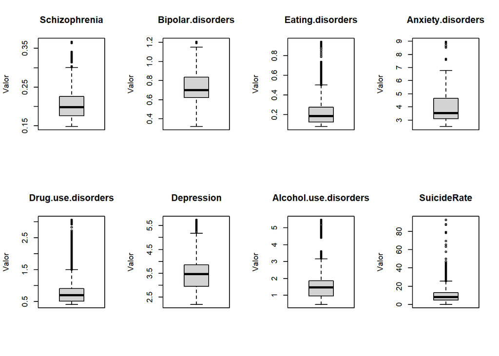

```r
variables <- c("Schizophrenia", "Bipolar.disorders", "Eating.disorders",
                       "Anxiety.disorders", "Drug.use.disorders", "Depression",
                       "Alcohol.use.disorders", "SuicideRate")
par(mfrow=c(2, 4))
for (variable in variables) {
  boxplot(dataMH[[variable]], main = variable, ylab = "Valor")
}
```

Según los datos observados, podemos comentar que: Schizophrenia: La distribución de la variable “Schizophrenia” muestra una mediana aproximadamente en 0.1981, con un rango intercuartílico (IQR) que va desde aproximadamente 0.1764 hasta 0.2261. Los valores oscilan entre 0.1483 y 0.3671, con algunos valores atípicos en el extremo superior del rango.

Bipolar.disorders: Para la variable “Bipolar.disorders”, la mediana se encuentra alrededor de 0.6993, con un IQR que va desde aproximadamente 0.6224 hasta 0.8348. No hay valores atípicos en el extremo inferior del rango pero sí en el extremo superior del mismo, con valores máximos de 1.2066.

Eating.disorders: La mediana de la variable “Eating.disorders” es aproximadamente 0.18337, con un IQR que va desde alrededor de 0.12392 hasta 0.27564. Se observan valores atípicos en el extremo superior del rango, con un mínimo de 0.07638 y un máximo de 0.94399.

Drug.use.disorders: La mediana de la variable “Drug.use.disorders” es aproximadamente 0.6895, con un IQR que va desde alrededor de 0.5126 hasta 0.9057 En esta variable tampoco se observan valores atípicos en el extremo inferior del rango pero sí se observan gran cantidad de valores fuera del rango en el extremo superior del mismo, con valores máximos 4 veces por encima de la mediana.

Depression: La mediana de la variable “Depression” es aproximadamente 3.470, con un IQR que va desde alrededor de 2.962 hasta 3.861. En esta variable tampoco se observan valores atípicos en el extremo inferior del rango pero sí en el extremo superior del mismo, con valores máximos de 5.745.

SuicideRate: La mediana de la variable “SuicideRate” es aproximadamente 8.225, con un IQR que va desde alrededor de 4.888 hasta 13.125. Se observan valores atípicos en el extremo superior del rango, con un mínimo de 0.000 y un máximo de 92.641. Cabe resaltar que el el valor mínimo se acerca más a la media y la mediana que el valor máximo.

```r
dataMH_disorders <- dataMH[, c("Schizophrenia", "Bipolar.disorders", "Eating.disorders","Anxiety.disorders", "Drug.use.disorders", "Depression", "Alcohol.use.disorders")]

head(dataMH_disorders)
```

```
##   Schizophrenia Bipolar.disorders Eating.disorders Anxiety.disorders
## 1      0.161621          0.700015         0.086021          4.827047
## 2      0.161957          0.700499         0.086517          4.831409
## 3      0.162414          0.701141         0.087023          4.838318
## 4      0.162916          0.701860         0.087189          4.845538
## 5      0.163377          0.702556         0.088158          4.851512
## 6      0.163706          0.703078         0.088933          4.854684
##   Drug.use.disorders Depression Alcohol.use.disorders
## 1           1.788395   4.118610              0.662479
## 2           1.839123   4.121381              0.661158
## 3           1.934326   4.124928              0.659213
## 4           2.051106   4.125230              0.657354
## 5           2.163044   4.126384              0.656132
## 6           2.247443   4.126908              0.655686
```

```r
missing_values_mh_d <- colSums(is.na(dataMH_disorders))
print("Datos faltantes en datosMH:")
```

```
## [1] "Datos faltantes en datosMH:"
```

```r
print(missing_values_mh_d)
```

```
##         Schizophrenia     Bipolar.disorders      Eating.disorders
##                     0                     0                     0
##     Anxiety.disorders    Drug.use.disorders            Depression
##                     0                     0                     0
## Alcohol.use.disorders
##                     0
```

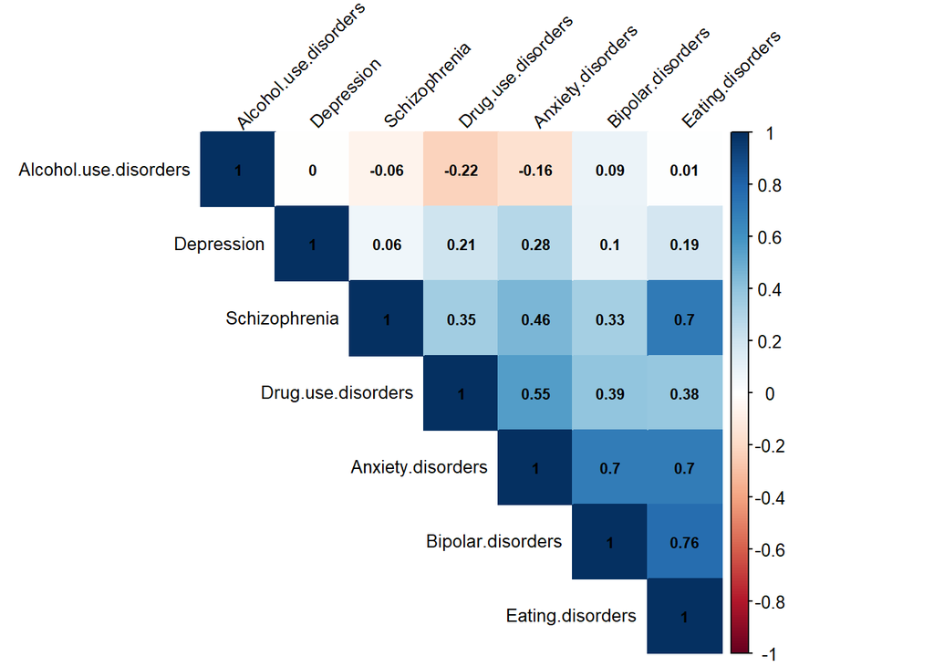

```r
library(corrplot)
correlation_matrix_disorders <- cor(dataMH_disorders, use = "pairwise.complete.obs")
plot.new()
corrplot(correlation_matrix_disorders, method = "color", type = "upper", order = "hclust",
         tl.cex = 0.8, tl.col = "black", tl.srt = 45, addCoef.col = "black", number.cex = 0.7)
```

En el análisis de correlación, se evalúa la relación lineal entre pares de variables. Los resultados indican que hay asociaciones significativas entre varios trastornos de salud mental en el conjunto de datos analizado:

Eating Disorders y Schizophrenia (0.70): La fuerte correlación positiva sugiere una conexión entre trastornos alimentarios y esquizofrenia. Este hallazgo puede tener implicaciones importantes ya que indica que la presencia de un trastorno podría estar asociada con un mayor riesgo o prevalencia del otro.

Anxiety Disorders y Schizophrenia (0.46): La correlación positiva considerable entre la ansiedad y la esquizofrenia indica una relación entre estos dos trastornos. Este hallazgo podría tener consecuencias entre los síntomas de ansiedad en pacientes con esquizofrenia.

Alcohol Use Disorders y otras variables: La falta de correlaciones significativas con “Alcohol.use.disorders” sugiere que los trastornos por consumo de alcohol pueden tener una dinámica diferente o menos asociación lineal con los otros trastornos mentales analizados. Esto podría indicar que los factores subyacentes o los desencadenantes de los trastornos por consumo de alcohol pueden ser menos directamente relacionados con los factores que contribuyen a los otros trastornos mentales en consideración.

```r
dataMH_res <- dataMH[, c("Schizophrenia", "Bipolar.disorders", "Eating.disorders",
                                     "Anxiety.disorders", "Drug.use.disorders", "Depression",
                                     "Alcohol.use.disorders", "SuicideRate")]
head(dataMH_res)
```

```
##   Schizophrenia Bipolar.disorders Eating.disorders Anxiety.disorders
## 1      0.161621          0.700015         0.086021          4.827047
## 2      0.161957          0.700499         0.086517          4.831409
## 3      0.162414          0.701141         0.087023          4.838318
## 4      0.162916          0.701860         0.087189          4.845538
## 5      0.163377          0.702556         0.088158          4.851512
## 6      0.163706          0.703078         0.088933          4.854684
##   Drug.use.disorders Depression Alcohol.use.disorders SuicideRate
## 1           1.788395   4.118610              0.662479        4.91
## 2           1.839123   4.121381              0.661158        5.03
## 3           1.934326   4.124928              0.659213        5.00
## 4           2.051106   4.125230              0.657354        4.95
## 5           2.163044   4.126384              0.656132        5.03
## 6           2.247443   4.126908              0.655686        4.97
```

```r
summary(dataMH_res)
```

```
##  Schizophrenia    Bipolar.disorders Eating.disorders  Anxiety.disorders
##  Min.   :0.1483   Min.   :0.3189    Min.   :0.07638   Min.   :2.503
##  1st Qu.:0.1764   1st Qu.:0.6224    1st Qu.:0.12392   1st Qu.:3.095
##  Median :0.1981   Median :0.6993    Median :0.18337   Median :3.523
##  Mean   :0.2057   Mean   :0.7261    Mean   :0.23756   Mean   :3.942
##  3rd Qu.:0.2261   3rd Qu.:0.8348    3rd Qu.:0.27564   3rd Qu.:4.652
##  Max.   :0.3671   Max.   :1.2066    Max.   :0.94399   Max.   :8.967
##  Drug.use.disorders   Depression    Alcohol.use.disorders  SuicideRate
##  Min.   :0.4027     Min.   :2.194   Min.   :0.4499        Min.   : 0.000
##  1st Qu.:0.5126     1st Qu.:2.962   1st Qu.:0.9618        1st Qu.: 4.888
##  Median :0.6895     Median :3.470   Median :1.4707        Median : 8.225
##  Mean   :0.8207     Mean   :3.460   Mean   :1.5626        Mean   :10.520
##  3rd Qu.:0.9057     3rd Qu.:3.861   3rd Qu.:1.8482        3rd Qu.:13.125
##  Max.   :3.0600     Max.   :5.745   Max.   :5.4747        Max.   :92.641
```

A continuación, observamos la correlación entre los trastornos de enfermedades mentales con la tasa de suicidios.

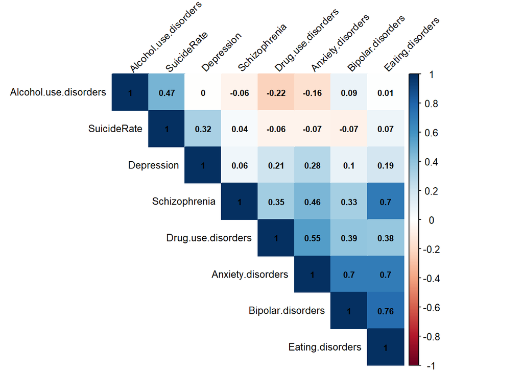

```r
correlation_matrix <- cor(dataMH_res, use = "pairwise.complete.obs")
plot.new()
corrplot(correlation_matrix, method = "color", type = "upper", order = "hclust",
         tl.cex = 0.8, tl.col = "black", tl.srt = 45, addCoef.col = "black", number.cex = 0.7)
```

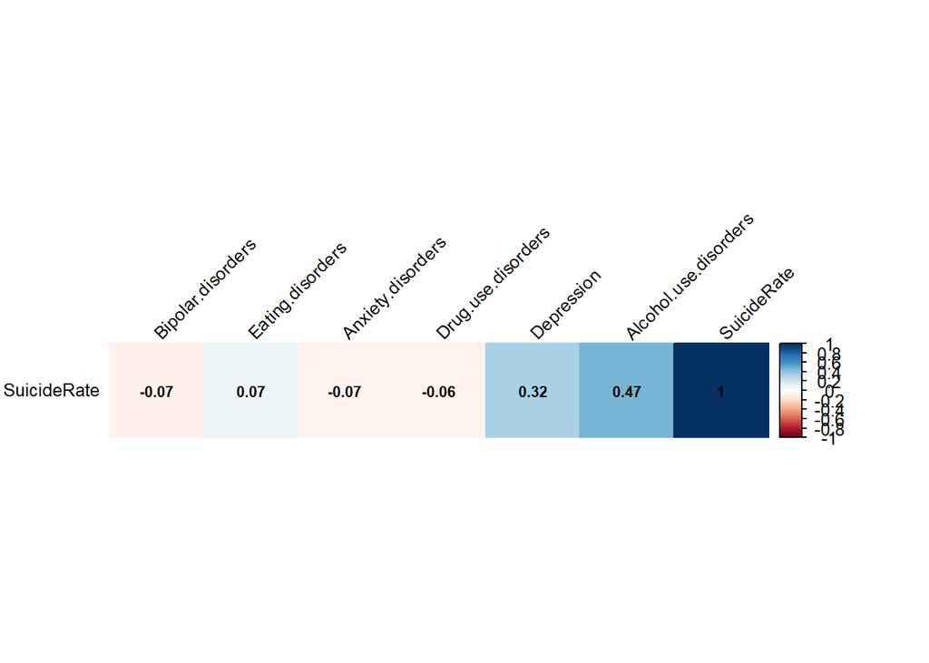

```r
correlation_subset <- correlation_matrix["SuicideRate", -1, drop = FALSE]
plot.new()
corrplot(correlation_subset, method = "color", type = "upper", tl.cex = 0.8, tl.col = "black", tl.srt = 45, addCoef.col = "black", number.cex = 0.7)
```

```r
print(correlation_subset)
```

```
##             Bipolar.disorders Eating.disorders Anxiety.disorders
## SuicideRate       -0.07118898       0.07139989       -0.06832945
##             Drug.use.disorders Depression Alcohol.use.disorders SuicideRate
## SuicideRate        -0.06154155   0.320269             0.4678559           1
```

En este análisis de correlación entre los trastornos de enfermedades mentales con la tasa de suicidios, observamos que destacan correlaciones positivas entre dos trastornos de enfermedades mentales y los valores del resto están cercanos a cero. Concretamente, la correlación más fuerte entre un trastorno de enfermedad mental con la tasa de nivel de suicidio son los problemas de consumo de alcohol con un 0.47, seguida por la depresión (0.32). Este aspecto es muy importante puesto que, como podemos observar, los problemas con el uso del alcohol presenta una gran correlación con la tasa de suicidios en el mundo aunque no presente una correlación significativa con el resto de enfermedades mentales.Por otro lado, se observan correlaciones cercanas a cero, entre los trastornos bipolares (-0.07) y ansiedad (-0.07) respecto a la tasa de suicidios.

Los resultados de este estudio subrayan la importancia de considerar la relación entre la salud mental y el suicidio, brindando perspectivas útiles para la investigación e incluso el diagnóstico médico.